# Project: Investigate a Dataset - [tmdb-movies]

- Introduction
- Data Wrangling
- Exploratory Data Analysis
- Conclusions

## Introduction

### Dataset Description

The TMDb movie dataset includes details on 10,000 films sourced from The Movie Database (TMDb). It provides various information about each movie, such as revenue, budget, original title, genres, release date, and more. I aim to explore and uncover additional interesting patterns within this dataset.

### Question(s) for Analysis

```python
# Import Python necessary  package essential for our analysis
import pandas as pd
import numpy as np
import operator
import seaborn as sns
import matplotlib.pyplot as plt
%matplotlib inline
```

## Data Wrangling

### General Properties

```python
df = pd.read_csv('Data/tmdb-movies.csv')
```

```python
# Display the dataset information
df.info()
```

```
<class 'pandas.core.frame.DataFrame'>
RangeIndex: 10866 entries, 0 to 10865
Data columns (total 21 columns):
 #   Column                Non-Null Count  Dtype
---  ------                --------------  -----
 0   id                    10866 non-null  int64
 1   imdb_id               10856 non-null  object
 2   popularity            10866 non-null  float64
 3   budget                10866 non-null  int64
 4   revenue               10866 non-null  int64
 5   original_title        10866 non-null  object
 6   cast                  10790 non-null  object
 7   homepage              2936 non-null   object
 8   director              10822 non-null  object
 9   tagline               8042 non-null   object
 10  keywords              9373 non-null   object
 11  overview              10862 non-null  object
 12  runtime               10866 non-null  int64
 13  genres                10843 non-null  object
 14  production_companies  9836 non-null   object
 15  release_date          10866 non-null  object
 16  vote_count            10866 non-null  int64
 17  vote_average          10866 non-null  float64
 18  release_year          10866 non-null  int64
 19  budget_adj            10866 non-null  float64
 20  revenue_adj           10866 non-null  float64
dtypes: float64(4), int64(6), object(11)
memory usage: 1.7+ MB
```

```python
# Shape of our dataset.
print(df.shape)
```

```
(10866, 21)
```

```python
# Display summary statistics for the dataset
df.describe()
```

|  | id | popularity | budget | revenue | runtime | vote_count | vote_average | release_year | budget_adj | revenue_adj |
| --- | --- | --- | --- | --- | --- | --- | --- | --- | --- | --- |
| count | 10866.000000 | 10866.000000 | 1.086600e+04 | 1.086600e+04 | 10866.000000 | 10866.000000 | 10866.000000 | 10866.000000 | 1.086600e+04 | 1.086600e+04 |
| mean | 66064.177434 | 0.646441 | 1.462570e+07 | 3.982332e+07 | 102.070863 | 217.389748 | 5.974922 | 2001.322658 | 1.755104e+07 | 5.136436e+07 |
| std | 92130.136561 | 1.000185 | 3.091321e+07 | 1.170035e+08 | 31.381405 | 575.619058 | 0.935142 | 12.812941 | 3.430616e+07 | 1.446325e+08 |
| min | 5.000000 | 0.000065 | 0.000000e+00 | 0.000000e+00 | 0.000000 | 10.000000 | 1.500000 | 1960.000000 | 0.000000e+00 | 0.000000e+00 |
| 25% | 10596.250000 | 0.207583 | 0.000000e+00 | 0.000000e+00 | 90.000000 | 17.000000 | 5.400000 | 1995.000000 | 0.000000e+00 | 0.000000e+00 |
| 50% | 20669.000000 | 0.383856 | 0.000000e+00 | 0.000000e+00 | 99.000000 | 38.000000 | 6.000000 | 2006.000000 | 0.000000e+00 | 0.000000e+00 |
| 75% | 75610.000000 | 0.713817 | 1.500000e+07 | 2.400000e+07 | 111.000000 | 145.750000 | 6.600000 | 2011.000000 | 2.085325e+07 | 3.369710e+07 |
| max | 417859.000000 | 32.985763 | 4.250000e+08 | 2.781506e+09 | 900.000000 | 9767.000000 | 9.200000 | 2015.000000 | 4.250000e+08 | 2.827124e+09 |

```python
print(list(df.columns.values))
```

```
['id', 'imdb_id', 'popularity', 'budget', 'revenue', 'original_title', 'cast', 'homepage', 'director', 'tagline', 'keywords', 'overview', 'runtime', 'genres', 'production_companies', 'release_date', 'vote_count', 'vote_average', 'release_year', 'budget_adj', 'revenue_adj']
```

```python
df.head(10)
```

|  | id | imdb_id | popularity | budget | revenue | original_title | cast | homepage | director | tagline | ... | overview | runtime | genres | production_companies | release_date | vote_count | vote_average | release_year | budget_adj | revenue_adj |
| --- | --- | --- | --- | --- | --- | --- | --- | --- | --- | --- | --- | --- | --- | --- | --- | --- | --- | --- | --- | --- | --- |
| 0 | 135397 | tt0369610 | 32.985763 | 150000000 | 1513528810 | Jurassic World | Chris Pratt\|Bryce Dallas Howard\|Irrfan Khan\|Vi... | http://www.jurassicworld.com/ | Colin Trevorrow | The park is open. | ... | Twenty-two years after the events of Jurassic ... | 124 | Action\|Adventure\|Science Fiction\|Thriller | Universal Studios\|Amblin Entertainment\|Legenda... | 6/9/15 | 5562 | 6.5 | 2015 | 1.379999e+08 | 1.392446e+09 |
| 1 | 76341 | tt1392190 | 28.419936 | 150000000 | 378436354 | Mad Max: Fury Road | Tom Hardy\|Charlize Theron\|Hugh Keays-Byrne\|Nic... | http://www.madmaxmovie.com/ | George Miller | What a Lovely Day. | ... | An apocalyptic story set in the furthest reach... | 120 | Action\|Adventure\|Science Fiction\|Thriller | Village Roadshow Pictures\|Kennedy Miller Produ... | 5/13/15 | 6185 | 7.1 | 2015 | 1.379999e+08 | 3.481613e+08 |
| 2 | 262500 | tt2908446 | 13.112507 | 110000000 | 295238201 | Insurgent | Shailene Woodley\|Theo James\|Kate Winslet\|Ansel... | http://www.thedivergentseries.movie/#insurgent | Robert Schwentke | One Choice Can Destroy You | ... | Beatrice Prior must confront her inner demons ... | 119 | Adventure\|Science Fiction\|Thriller | Summit Entertainment\|Mandeville Films\|Red Wago... | 3/18/15 | 2480 | 6.3 | 2015 | 1.012000e+08 | 2.716190e+08 |
| 3 | 140607 | tt2488496 | 11.173104 | 200000000 | 2068178225 | Star Wars: The Force Awakens | Harrison Ford\|Mark Hamill\|Carrie Fisher\|Adam D... | http://www.starwars.com/films/star-wars-episod... | J.J. Abrams | Every generation has a story. | ... | Thirty years after defeating the Galactic Empi... | 136 | Action\|Adventure\|Science Fiction\|Fantasy | Lucasfilm\|Truenorth Productions\|Bad Robot | 12/15/15 | 5292 | 7.5 | 2015 | 1.839999e+08 | 1.902723e+09 |
| 4 | 168259 | tt2820852 | 9.335014 | 190000000 | 1506249360 | Furious 7 | Vin Diesel\|Paul Walker\|Jason Statham\|Michelle ... | http://www.furious7.com/ | James Wan | Vengeance Hits Home | ... | Deckard Shaw seeks revenge against Dominic Tor... | 137 | Action\|Crime\|Thriller | Universal Pictures\|Original Film\|Media Rights ... | 4/1/15 | 2947 | 7.3 | 2015 | 1.747999e+08 | 1.385749e+09 |
| 5 | 281957 | tt1663202 | 9.110700 | 135000000 | 532950503 | The Revenant | Leonardo DiCaprio\|Tom Hardy\|Will Poulter\|Domhn... | http://www.foxmovies.com/movies/the-revenant | Alejandro González Iñárritu | (n. One who has returned, as if from the dead.) | ... | In the 1820s, a frontiersman, Hugh Glass, sets... | 156 | Western\|Drama\|Adventure\|Thriller | Regency Enterprises\|Appian Way\|CatchPlay\|Anony... | 12/25/15 | 3929 | 7.2 | 2015 | 1.241999e+08 | 4.903142e+08 |
| 6 | 87101 | tt1340138 | 8.654359 | 155000000 | 440603537 | Terminator Genisys | Arnold Schwarzenegger\|Jason Clarke\|Emilia Clar... | http://www.terminatormovie.com/ | Alan Taylor | Reset the future | ... | The year is 2029. John Connor, leader of the r... | 125 | Science Fiction\|Action\|Thriller\|Adventure | Paramount Pictures\|Skydance Productions | 6/23/15 | 2598 | 5.8 | 2015 | 1.425999e+08 | 4.053551e+08 |
| 7 | 286217 | tt3659388 | 7.667400 | 108000000 | 595380321 | The Martian | Matt Damon\|Jessica Chastain\|Kristen Wiig\|Jeff ... | http://www.foxmovies.com/movies/the-martian | Ridley Scott | Bring Him Home | ... | During a manned mission to Mars, Astronaut Mar... | 141 | Drama\|Adventure\|Science Fiction | Twentieth Century Fox Film Corporation\|Scott F... | 9/30/15 | 4572 | 7.6 | 2015 | 9.935996e+07 | 5.477497e+08 |
| 8 | 211672 | tt2293640 | 7.404165 | 74000000 | 1156730962 | Minions | Sandra Bullock\|Jon Hamm\|Michael Keaton\|Allison... | http://www.minionsmovie.com/ | Kyle Balda\|Pierre Coffin | Before Gru, they had a history of bad bosses | ... | Minions Stuart, Kevin and Bob are recruited by... | 91 | Family\|Animation\|Adventure\|Comedy | Universal Pictures\|Illumination Entertainment | 6/17/15 | 2893 | 6.5 | 2015 | 6.807997e+07 | 1.064192e+09 |
| 9 | 150540 | tt2096673 | 6.326804 | 175000000 | 853708609 | Inside Out | Amy Poehler\|Phyllis Smith\|Richard Kind\|Bill Ha... | http://movies.disney.com/inside-out | Pete Docter | Meet the little voices inside your head. | ... | Growing up can be a bumpy road, and it's no ex... | 94 | Comedy\|Animation\|Family | Walt Disney Pictures\|Pixar Animation Studios\|W... | 6/9/15 | 3935 | 8.0 | 2015 | 1.609999e+08 | 7.854116e+08 |

10 rows × 21 columns

```python
# Display the number of missing values for each column .
df.isnull().sum()
```

```
id                         0
imdb_id                   10
popularity                 0
budget                     0
revenue                    0
original_title             0
cast                      76
homepage                7930
director                  44
tagline                 2824
keywords                1493
overview                   4
runtime                    0
genres                    23
production_companies    1030
release_date               0
vote_count                 0
vote_average               0
release_year               0
budget_adj                 0
revenue_adj                0
dtype: int64
```

```python
#fill the null values with zero using 'fillna' function
df=df.fillna(0)
```

### Data Cleaning

#### 1-remove duplicate rows from the dataset

```python
#counting the duplicates
sum(df.duplicated())
```

```
1
```

```python
#drop these duplicated rows
df.drop_duplicates(inplace=True)
df.shape
```

```
(10865, 21)
```

#### 2- remove the unused colums that are not needes in the analysis process

```python
#The columns like imdb_id, homepage,tagline, overview, budget_adj and revenue_adj are not required for my analysis
#I will drop these columns
df.drop(['imdb_id','homepage','tagline','overview','budget_adj','revenue_adj'],axis =1,inplace = True)
```

```python
df.shape
```

```
(10865, 15)
```

#### 3- changing Datetime Format

```python
# We need to change release_date from string to datetime format
df['release_date']=pd.to_datetime(df['release_date'])
df['release_date'].head()
```

```
0   2015-06-09
1   2015-05-13
2   2015-03-18
3   2015-12-15
4   2015-04-01
Name: release_date, dtype: datetime64[ns]
```

#### 4- Seperate Data contained in Cast & Genres into Multiple values

```python
# Columns like cast & genres contain several values contained in a single cell separated by the "|" ,
# so we need to separate these values to make a more appropriate analysis.
def seprate_values(col):
    new_cols=(df[col].str.split('|', expand=True).rename(columns=lambda x: f"{col}_{x+1}"))
    return new_cols
```

```python
df_gen = seprate_values('genres')
df_cast = seprate_values('cast')
```

```python
df['cast'],df['genres']=df_cast['cast_1'],df_gen['genres_1']
```

```python
display(df['cast'].value_counts().nlargest(10))
print('-'*60)
display(df['genres'].value_counts().nlargest(10))
```

```
Nicolas Cage             50
Robert De Niro           42
Bruce Willis             39
Clint Eastwood           38
Tom Hanks                37
Sylvester Stallone       37
Johnny Depp              37
Steven Seagal            35
Jean-Claude Van Damme    35
Robin Williams           33
Name: cast, dtype: int64
```

```
Drama          2453
Comedy         2319
Action         1590
Horror          915
Adventure       586
Thriller        491
Documentary     432
Animation       403
Crime           380
Fantasy         272
Name: genres, dtype: int64
```

```python
df.info()
```

```
<class 'pandas.core.frame.DataFrame'>
Int64Index: 10865 entries, 0 to 10865
Data columns (total 15 columns):
 #   Column                Non-Null Count  Dtype
---  ------                --------------  -----
 0   id                    10865 non-null  int64
 1   popularity            10865 non-null  float64
 2   budget                10865 non-null  int64
 3   revenue               10865 non-null  int64
 4   original_title        10865 non-null  object
 5   cast                  10789 non-null  object
 6   director              10865 non-null  object
 7   keywords              10865 non-null  object
 8   runtime               10865 non-null  int64
 9   genres                10842 non-null  object
 10  production_companies  10865 non-null  object
 11  release_date          10865 non-null  datetime64[ns]
 12  vote_count            10865 non-null  int64
 13  vote_average          10865 non-null  float64
 14  release_year          10865 non-null  int64
dtypes: datetime64[ns](1), float64(2), int64(6), object(6)
memory usage: 1.3+ MB
```

## Exploratory Data Analysis

### Research Question 1 (Which year has the most movie releases?)

```python
#count the number of movies in each year
data_s1=df.groupby('release_year').count()['id']
data_s1.tail()
```

```
release_year
2011    540
2012    588
2013    659
2014    700
2015    629
Name: id, dtype: int64
```

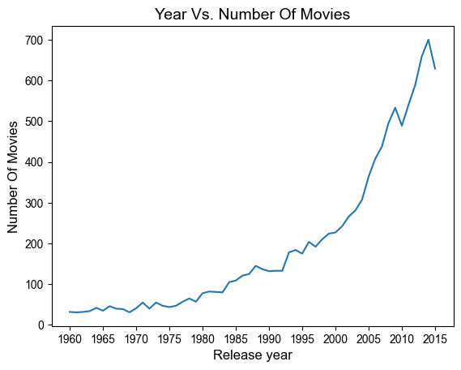

```python
data_s1.plot(xticks = np.arange(1960,2016,5))
sns.set(rc={'figure.figsize':(14,5)})
plt.title("Year Vs. Number Of Movies",fontsize = 14)
plt.xlabel('Release year',fontsize = 12)
plt.ylabel('Number Of Movies',fontsize = 12)
sns.set_style("whitegrid")
```

Based on the plot and data, the year with the most movie releases is 2014, with a total of 700 movies. This is followed by 2013, which saw 659 releases, and 2015, with 629 releases.

### Research Question 2 (Which movie has the highest and lowest revenue?)

```python
def find_minmax(x):
    #Find the index of lowest profit movie.
    min_index = df[x].idxmin()
    #Find the index of Highest profit movie.
    high_index = df[x].idxmax()
    high = pd.DataFrame(df.loc[high_index,:])
    low = pd.DataFrame(df.loc[min_index,:])
    #print the movie with the highest and the lowest profit
    print("Movie Which Has Highest "+ x + " : ",df['original_title'][high_index])
    print("Movie Which Has Lowest "+ x + "  : ",df['original_title'][min_index])
    return pd.concat([high,low],axis = 1)
```

```python
find_minmax('revenue')
```

```
Movie Which Has Highest revenue :  Avatar
Movie Which Has Lowest revenue  :  Wild Card
```

|  | 1386 | 48 |
| --- | --- | --- |
| id | 19995 | 265208 |
| popularity | 9.432768 | 2.93234 |
| budget | 237000000 | 30000000 |
| revenue | 2781505847 | 0 |
| original_title | Avatar | Wild Card |
| cast | Sam Worthington | Jason Statham |
| director | James Cameron | Simon West |
| keywords | culture clash\|future\|space war\|space colony\|so... | gambling\|bodyguard\|remake |
| runtime | 162 | 92 |
| genres | Action | Thriller |
| production_companies | Ingenious Film Partners\|Twentieth Century Fox ... | Current Entertainment\|Lionsgate\|Sierra / Affin... |
| release_date | 2009-12-10 00:00:00 | 2015-01-14 00:00:00 |
| vote_count | 8458 | 481 |
| vote_average | 7.1 | 5.3 |
| release_year | 2009 | 2015 |

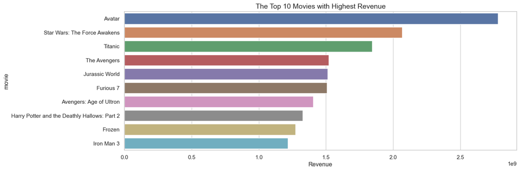

```python
#The top 10 movies which have the highest revenue.
#New data frame with the column'revenue' column sorted in decending order
info = pd.DataFrame(df['revenue'].sort_values(ascending = False))
info['original_title'] = df['original_title']
data_s2 = list(map(str,(info['original_title'])))

x = list(data_s2[:10])
y = list(info['revenue'][:10])

ax= sns.barplot(x=y,y=x)
sns.set(rc={'figure.figsize':(12,5)})
ax.set_title("The Top 10 Movies with Highest Revenue",fontsize = 14)
ax.set_xlabel("Revenue",fontsize = 12)
ax.set_ylabel("movie",fontsize = 12)

sns.set_style("darkgrid")
```

### Research Question 3 (Most Frequent star cast?)

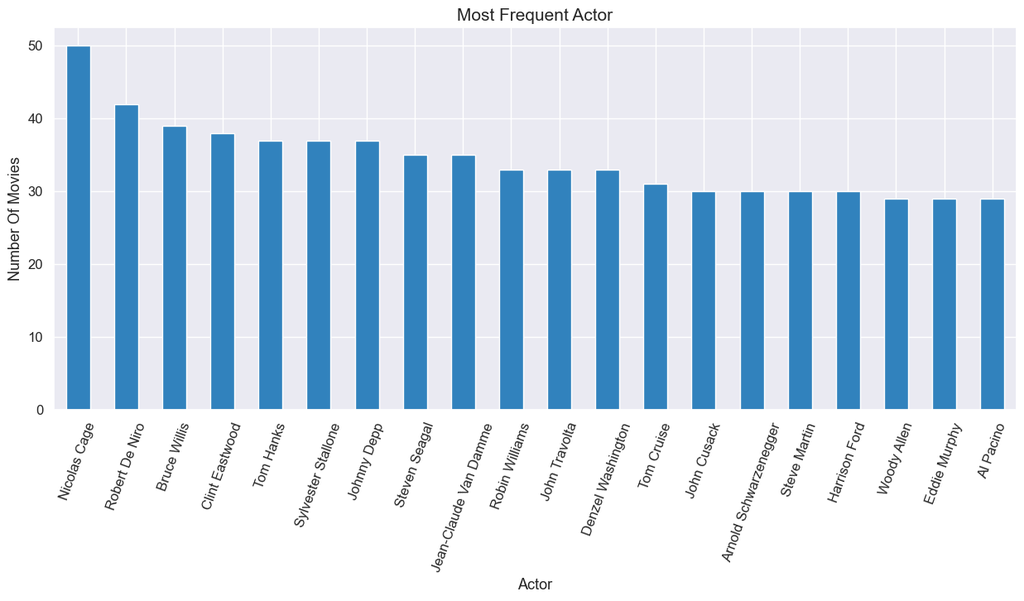

```python
#conts each of the cast and return.
count_actor_flims = df['cast'].value_counts(ascending=False)

#plot the barh plot.
count_actor_flims.iloc[:20].plot.bar(figsize=(15,6),colormap= 'tab20c',fontsize=12)

#setup the title and the labels of the plot.
plt.title("Most Frequent Actor",fontsize=15)
plt.xticks(rotation = 70)
plt.xlabel('Actor',fontsize=13)
plt.ylabel("Number Of Movies",fontsize= 13)
sns.set_style("whitegrid")
```

The plot above reveals that Nicolas Cage is the actor with the most movie appearances, featuring in around 50 films.

### Research Question 4 (Which movie has the highest and lowest budget?)

```python
df['budget'] = df['budget'].replace(0,np.NAN)
find_minmax('budget')
```

```
Movie Which Has Highest budget :  The Warrior's Way
Movie Which Has Lowest budget  :  Fear Clinic
```

|  | 2244 | 1151 |
| --- | --- | --- |
| id | 46528 | 287524 |
| popularity | 0.25054 | 0.177102 |
| budget | 425000000.0 | 1.0 |
| revenue | 11087569 | 0 |
| original_title | The Warrior's Way | Fear Clinic |
| cast | Kate Bosworth | Thomas Dekker |
| director | Sngmoo Lee | Robert Hall |
| keywords | assassin\|small town\|revenge\|deception\|super speed | phobia\|doctor\|fear |
| runtime | 100 | 95 |
| genres | Adventure | Horror |
| production_companies | Boram Entertainment Inc. | Dry County Films\|Anchor Bay Entertainment\|Movi... |
| release_date | 2010-12-02 00:00:00 | 2014-10-31 00:00:00 |
| vote_count | 74 | 15 |
| vote_average | 6.4 | 4.1 |
| release_year | 2010 | 2014 |

[figure not shown]

```python
#New data frame with the 'budget' column sorted in decending order
info = pd.DataFrame(df['budget'].sort_values(ascending = False))
info['original_title'] = df['original_title']
data_s3 = list(map(str,(info['original_title'])))

#extract the top 10 budget movies data from the list and dataframe.
x = list(data_s3[:15])
y = list(info['budget'][:15])

#plot the figure and setup the title and labels.
ax = sns.barplot(x=y,y=x)
sns.set(rc={'figure.figsize':(12,5)})
ax.set_title("The Top 10 Moviews with Highest Budget",fontsize = 15)
ax.set_xlabel("Budget",fontsize = 12)
ax.set_ylabel("Movie",fontsize = 12)
sns.set_style("darkgrid")
```

The results show that "The Warrior's Way" has the largest budget, amounting to 425 million dollars, while "Fear Clinic" has the smallest budget at just 1 dollar.

### Research Question 5 (Which month has the highest number of movie releases throught all the years?)

```
1      919
2      691
3      822
4      797
5      809
6      827
7      799
8      918
9     1331
10    1153
11     814
12     985
Name: release_date, dtype: int64
```

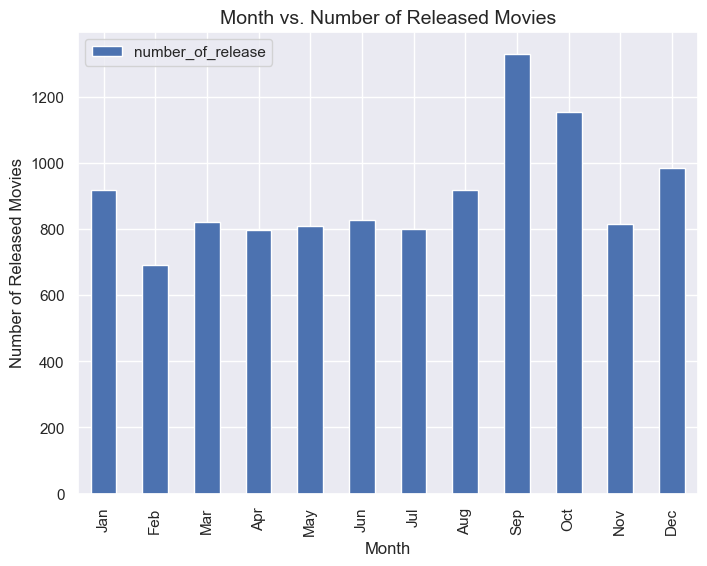

```python
df['release_date']=pd.to_datetime(df['release_date'])
number_of_release=df['release_date'].dt.month.value_counts().sort_index()
print(number_of_release)

months=['Jan','Feb','Mar','Apr','May','Jun','Jul','Aug','Sep','Oct','Nov','Dec']
number_of_release = pd.DataFrame(number_of_release)
number_of_release['month'] = months
number_of_release.rename(columns = {'release_date':'number_of_release'},inplace=True)
number_of_release.plot(x='month',kind='bar',fontsize = 11,figsize=(8,6))
plt.title('Month vs. Number of Released Movies',fontsize = 14)
plt.xlabel('Month',fontsize = 12)
plt.ylabel('Number of Released Movies',fontsize = 12)
```

The plot shows that September has the highest number of movie releases, with 1331 films released during that month.

Despite these findings, the project faced several limitations primarily related to the dataset's quality:

- Data Insufficiency: Although the dataset contains over 10,000 rows, it is insufficient for precise conclusions. Many data columns are irrelevant, and numerous entries contain missing values (NANs), which impact the analysis. A better approach to web scraping or sourcing data from a different provider could improve data quality.
- Data Quality: Much of the remaining data is zero-valued and treated as missing, leaving a limited amount of clean data for analysis.
- Outdated Data: The dataset is outdated, and significant changes in the cinema industry over the past few years—such as the rise of streaming services like Netflix, HBO, and Disney+, as well as the impact of the global pandemic—affect the relevance of the conclusions.

## 3. Submitting your Project

```python
# Convert this notebook to an .html file
!python -m nbconvert --to html Investigate_a_Dataset.ipynb
```

```
[NbConvertApp] Converting notebook Investigate_a_Dataset.ipynb to html
[NbConvertApp] Writing 1059732 bytes to Investigate_a_Dataset.html
```